# Risk Factor Analysis

## Outcome Variable

**Outcome Variable:** y_rate_len

## Predictor Variables

**Intervention Variable:** nchldlt5

**Adjustment Set:**

- arm
- W_mage
- meducyrs
- feducyrs
- hhwealth_quart
- hfoodsec
- W_mhtcm
- W_mwtkg
- W_mbmi
- W_nrooms
- W_parity
- impfloor
- impsan
- safeh20
- delta_W_mage
- delta_meducyrs
- delta_feducyrs
- delta_hhwealth_quart
- delta_hfoodsec
- delta_W_mhtcm
- delta_W_mwtkg
- delta_W_mbmi
- delta_W_nrooms
- delta_W_parity
- delta_impfloor
- delta_impsan
- delta_safeh20

## Stratifying Variables

The analysis was stratified on these variable(s):

- agecat
- studyid
- country

## Data Summary

| agecat | studyid | country | nchldlt5 | n_cell | n |
| --- | --- | --- | --- | --- | --- |
| 0-3 months | IRC | INDIA | 1 | 82 | 377 |
| 0-3 months | IRC | INDIA | 2+ | 295 | 377 |
| 0-3 months | JiVitA-3 | BANGLADESH | 1 | 12370 | 19860 |
| 0-3 months | JiVitA-3 | BANGLADESH | 2+ | 7490 | 19860 |
| 0-3 months | NIH-Crypto | BANGLADESH | 1 | 512 | 721 |
| 0-3 months | NIH-Crypto | BANGLADESH | 2+ | 209 | 721 |
| 0-3 months | PROVIDE | BANGLADESH | 1 | 471 | 640 |
| 0-3 months | PROVIDE | BANGLADESH | 2+ | 169 | 640 |
| 3-6 months | IRC | INDIA | 1 | 87 | 397 |
| 3-6 months | IRC | INDIA | 2+ | 310 | 397 |
| 3-6 months | JiVitA-3 | BANGLADESH | 1 | 8103 | 12572 |
| 3-6 months | JiVitA-3 | BANGLADESH | 2+ | 4469 | 12572 |
| 3-6 months | NIH-Crypto | BANGLADESH | 1 | 492 | 695 |
| 3-6 months | NIH-Crypto | BANGLADESH | 2+ | 203 | 695 |
| 3-6 months | PROVIDE | BANGLADESH | 1 | 434 | 598 |
| 3-6 months | PROVIDE | BANGLADESH | 2+ | 164 | 598 |
| 3-6 months | TanzaniaChild2 | TANZANIA, UNITED REPUBLIC OF | 1 | 1146 | 1656 |
| 3-6 months | TanzaniaChild2 | TANZANIA, UNITED REPUBLIC OF | 2+ | 510 | 1656 |
| 6-9 months | IRC | INDIA | 1 | 89 | 407 |
| 6-9 months | IRC | INDIA | 2+ | 318 | 407 |
| 6-9 months | LCNI-5 | MALAWI | 1 | 261 | 557 |
| 6-9 months | LCNI-5 | MALAWI | 2+ | 296 | 557 |
| 6-9 months | NIH-Crypto | BANGLADESH | 1 | 488 | 688 |
| 6-9 months | NIH-Crypto | BANGLADESH | 2+ | 200 | 688 |
| 6-9 months | PROVIDE | BANGLADESH | 1 | 410 | 565 |
| 6-9 months | PROVIDE | BANGLADESH | 2+ | 155 | 565 |
| 6-9 months | TanzaniaChild2 | TANZANIA, UNITED REPUBLIC OF | 1 | 1036 | 1480 |
| 6-9 months | TanzaniaChild2 | TANZANIA, UNITED REPUBLIC OF | 2+ | 444 | 1480 |
| 9-12 months | iLiNS-Zinc | BURKINA FASO | 1 | 364 | 1101 |
| 9-12 months | iLiNS-Zinc | BURKINA FASO | 2+ | 737 | 1101 |

[output cut: 52 more lines]

The following strata were considered:

- agecat: 0-3 months, studyid: IRC, country: INDIA
- agecat: 0-3 months, studyid: JiVitA-3, country: BANGLADESH
- agecat: 0-3 months, studyid: NIH-Crypto, country: BANGLADESH
- agecat: 0-3 months, studyid: PROVIDE, country: BANGLADESH
- agecat: 12-15 months, studyid: iLiNS-Zinc, country: BURKINA FASO
- agecat: 12-15 months, studyid: IRC, country: INDIA
- agecat: 12-15 months, studyid: LCNI-5, country: MALAWI
- agecat: 12-15 months, studyid: NIH-Crypto, country: BANGLADESH
- agecat: 12-15 months, studyid: PROVIDE, country: BANGLADESH
- agecat: 12-15 months, studyid: TanzaniaChild2, country: TANZANIA, UNITED REPUBLIC OF
- agecat: 15-18 months, studyid: iLiNS-Zinc, country: BURKINA FASO
- agecat: 15-18 months, studyid: IRC, country: INDIA
- agecat: 15-18 months, studyid: LCNI-5, country: MALAWI
- agecat: 15-18 months, studyid: NIH-Crypto, country: BANGLADESH
- agecat: 15-18 months, studyid: PROVIDE, country: BANGLADESH
- agecat: 15-18 months, studyid: TanzaniaChild2, country: TANZANIA, UNITED REPUBLIC OF
- agecat: 18-21 months, studyid: IRC, country: INDIA
- agecat: 18-21 months, studyid: LCNI-5, country: MALAWI
- agecat: 18-21 months, studyid: NIH-Crypto, country: BANGLADESH
- agecat: 18-21 months, studyid: PROVIDE, country: BANGLADESH
- agecat: 18-21 months, studyid: TanzaniaChild2, country: TANZANIA, UNITED REPUBLIC OF
- agecat: 21-24 months, studyid: IRC, country: INDIA
- agecat: 21-24 months, studyid: LCNI-5, country: MALAWI
- agecat: 21-24 months, studyid: NIH-Crypto, country: BANGLADESH
- agecat: 21-24 months, studyid: PROVIDE, country: BANGLADESH
- agecat: 3-6 months, studyid: IRC, country: INDIA
- agecat: 3-6 months, studyid: JiVitA-3, country: BANGLADESH
- agecat: 3-6 months, studyid: NIH-Crypto, country: BANGLADESH
- agecat: 3-6 months, studyid: PROVIDE, country: BANGLADESH
- agecat: 3-6 months, studyid: TanzaniaChild2, country: TANZANIA, UNITED REPUBLIC OF
- agecat: 6-9 months, studyid: IRC, country: INDIA
- agecat: 6-9 months, studyid: LCNI-5, country: MALAWI
- agecat: 6-9 months, studyid: NIH-Crypto, country: BANGLADESH
- agecat: 6-9 months, studyid: PROVIDE, country: BANGLADESH
- agecat: 6-9 months, studyid: TanzaniaChild2, country: TANZANIA, UNITED REPUBLIC OF
- agecat: 9-12 months, studyid: iLiNS-Zinc, country: BURKINA FASO
- agecat: 9-12 months, studyid: IRC, country: INDIA
- agecat: 9-12 months, studyid: LCNI-5, country: MALAWI
- agecat: 9-12 months, studyid: NIH-Crypto, country: BANGLADESH
- agecat: 9-12 months, studyid: PROVIDE, country: BANGLADESH
- agecat: 9-12 months, studyid: TanzaniaChild2, country: TANZANIA, UNITED REPUBLIC OF

### Dropped Strata

Some strata were dropped due to rare outcomes:

- agecat: 18-21 months, studyid: TanzaniaChild2, country: TANZANIA, UNITED REPUBLIC OF

## Methods Detail

We’re interested in the causal parameters $E[Y_a]$ for all values of $a \in \mathcal{A}$. These parameters represent the mean outcome if, possibly contrary to fact, we intervened to set all units to have $A=a$. Under the randomization and positivity assumptions, these are identified by the statistical parameters $\psi_a=E_W[E_{Y|A,W}(Y|A=a,W)]$. In addition, we’re interested in the mean of $Y$, $E[Y]$ under no intervention (the observed mean). We will estimate these parameters by using SuperLearner to fit the relevant likelihood factors – $E_{Y|A,W}(Y|A=a,W)$ and $p(A=a|W)$, and then updating our likelihood fit using a joint TMLE.

For unadjusted analyses ($W=\{\}$), initial likelihoods were estimated using Lrnr_glm to estimate the simple $E(Y|A)$ and Lrnr_mean to estimate $p(A)$. For adjusted analyses, a small library containing Lrnr_glmnet, Lrnr_xgboost, and Lrnr_mean was used.

Having estimated these parameters, we will then use the delta method to estimate relative risks and attributable risks relative to a prespecified baseline level of $A$.

# Results Detail

## Results Plots

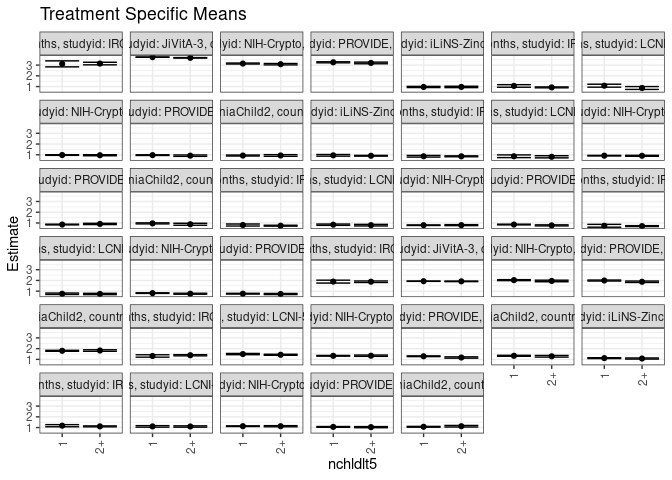

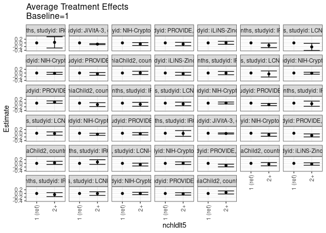

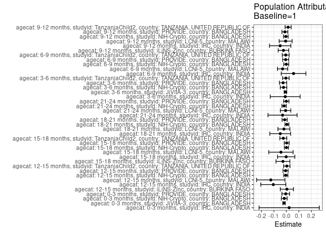

## Results Table

### Parameter: TSM

| agecat | studyid | country | intervention_level | baseline_level | estimate | ci_lower | ci_upper |
| --- | --- | --- | --- | --- | --- | --- | --- |
| 0-3 months | IRC | INDIA | 1 | NA | 3.1157409 | 2.8370672 | 3.3944147 |
| 0-3 months | IRC | INDIA | 2+ | NA | 3.1451595 | 3.0249105 | 3.2654086 |
| 0-3 months | JiVitA-3 | BANGLADESH | 1 | NA | 3.7421266 | 3.7281863 | 3.7560670 |
| 0-3 months | JiVitA-3 | BANGLADESH | 2+ | NA | 3.6766416 | 3.6520936 | 3.7011895 |
| 0-3 months | NIH-Crypto | BANGLADESH | 1 | NA | 3.1458853 | 3.1018777 | 3.1898930 |
| 0-3 months | NIH-Crypto | BANGLADESH | 2+ | NA | 3.0851662 | 3.0197868 | 3.1505456 |
| 0-3 months | PROVIDE | BANGLADESH | 1 | NA | 3.2627848 | 3.2131217 | 3.3124480 |
| 0-3 months | PROVIDE | BANGLADESH | 2+ | NA | 3.2010708 | 3.1243097 | 3.2778319 |
| 3-6 months | IRC | INDIA | 1 | NA | 1.8900568 | 1.7541480 | 2.0259656 |
| 3-6 months | IRC | INDIA | 2+ | NA | 1.8785668 | 1.8064165 | 1.9507172 |
| 3-6 months | JiVitA-3 | BANGLADESH | 1 | NA | 1.9278698 | 1.9128617 | 1.9428780 |
| 3-6 months | JiVitA-3 | BANGLADESH | 2+ | NA | 1.9140988 | 1.8866020 | 1.9415957 |
| 3-6 months | NIH-Crypto | BANGLADESH | 1 | NA | 2.0284410 | 1.9841970 | 2.0726851 |
| 3-6 months | NIH-Crypto | BANGLADESH | 2+ | NA | 1.9498465 | 1.8782976 | 2.0213954 |
| 3-6 months | PROVIDE | BANGLADESH | 1 | NA | 1.9921274 | 1.9467497 | 2.0375051 |
| 3-6 months | PROVIDE | BANGLADESH | 2+ | NA | 1.8732045 | 1.8058133 | 1.9405958 |
| 3-6 months | TanzaniaChild2 | TANZANIA, UNITED REPUBLIC OF | 1 | NA | 1.7972874 | 1.7520228 | 1.8425519 |
| 3-6 months | TanzaniaChild2 | TANZANIA, UNITED REPUBLIC OF | 2+ | NA | 1.8230105 | 1.7516387 | 1.8943822 |
| 6-9 months | IRC | INDIA | 1 | NA | 1.3147512 | 1.2022141 | 1.4272883 |
| 6-9 months | IRC | INDIA | 2+ | NA | 1.3842273 | 1.3299546 | 1.4384999 |
| 6-9 months | LCNI-5 | MALAWI | 1 | NA | 1.4920050 | 1.4354072 | 1.5486027 |
| 6-9 months | LCNI-5 | MALAWI | 2+ | NA | 1.4260767 | 1.3771830 | 1.4749705 |
| 6-9 months | NIH-Crypto | BANGLADESH | 1 | NA | 1.3289772 | 1.2951704 | 1.3627841 |
| 6-9 months | NIH-Crypto | BANGLADESH | 2+ | NA | 1.3384239 | 1.2772378 | 1.3996101 |
| 6-9 months | PROVIDE | BANGLADESH | 1 | NA | 1.2881161 | 1.2517033 | 1.3245288 |
| 6-9 months | PROVIDE | BANGLADESH | 2+ | NA | 1.1707468 | 1.1098924 | 1.2316012 |
| 6-9 months | TanzaniaChild2 | TANZANIA, UNITED REPUBLIC OF | 1 | NA | 1.3303505 | 1.2849673 | 1.3757338 |
| 6-9 months | TanzaniaChild2 | TANZANIA, UNITED REPUBLIC OF | 2+ | NA | 1.2866611 | 1.2100093 | 1.3633129 |
| 9-12 months | iLiNS-Zinc | BURKINA FASO | 1 | NA | 1.1149633 | 1.0755241 | 1.1544026 |
| 9-12 months | iLiNS-Zinc | BURKINA FASO | 2+ | NA | 1.0783402 | 1.0274417 | 1.1292388 |
| 9-12 months | IRC | INDIA | 1 | NA | 1.1732429 | 1.0733343 | 1.2731515 |
| 9-12 months | IRC | INDIA | 2+ | NA | 1.1110630 | 1.0685099 | 1.1536162 |
| 9-12 months | LCNI-5 | MALAWI | 1 | NA | 1.1067117 | 1.0335411 | 1.1798822 |
| 9-12 months | LCNI-5 | MALAWI | 2+ | NA | 1.0996931 | 1.0381911 | 1.1611951 |
| 9-12 months | NIH-Crypto | BANGLADESH | 1 | NA | 1.1278754 | 1.0959090 | 1.1598417 |
| 9-12 months | NIH-Crypto | BANGLADESH | 2+ | NA | 1.1258935 | 1.0722501 | 1.1795368 |
| 9-12 months | PROVIDE | BANGLADESH | 1 | NA | 1.0616020 | 1.0240396 | 1.0991645 |
| 9-12 months | PROVIDE | BANGLADESH | 2+ | NA | 1.0389597 | 0.9858994 | 1.0920200 |
| 9-12 months | TanzaniaChild2 | TANZANIA, UNITED REPUBLIC OF | 1 | NA | 1.0714719 | 1.0324485 | 1.1104953 |
| 9-12 months | TanzaniaChild2 | TANZANIA, UNITED REPUBLIC OF | 2+ | NA | 1.1246682 | 1.0518054 | 1.1975310 |
| 12-15 months | iLiNS-Zinc | BURKINA FASO | 1 | NA | 0.9630482 | 0.9080097 | 1.0180867 |
| 12-15 months | iLiNS-Zinc | BURKINA FASO | 2+ | NA | 0.9675245 | 0.9060943 | 1.0289547 |
| 12-15 months | IRC | INDIA | 1 | NA | 1.0602054 | 0.9413781 | 1.1790327 |
| 12-15 months | IRC | INDIA | 2+ | NA | 0.9271886 | 0.8849857 | 0.9693915 |
| 12-15 months | LCNI-5 | MALAWI | 1 | NA | 1.0831886 | 0.9438373 | 1.2225399 |
| 12-15 months | LCNI-5 | MALAWI | 2+ | NA | 0.8675824 | 0.7355065 | 0.9996583 |
| 12-15 months | NIH-Crypto | BANGLADESH | 1 | NA | 0.9754847 | 0.9466496 | 1.0043198 |
| 12-15 months | NIH-Crypto | BANGLADESH | 2+ | NA | 0.9576983 | 0.9099098 | 1.0054869 |
| 12-15 months | PROVIDE | BANGLADESH | 1 | NA | 0.9663052 | 0.9317115 | 1.0008988 |
| 12-15 months | PROVIDE | BANGLADESH | 2+ | NA | 0.9180082 | 0.8532316 | 0.9827847 |
| 12-15 months | TanzaniaChild2 | TANZANIA, UNITED REPUBLIC OF | 1 | NA | 0.9285164 | 0.8844253 | 0.9726074 |
| 12-15 months | TanzaniaChild2 | TANZANIA, UNITED REPUBLIC OF | 2+ | NA | 0.9350057 | 0.8562036 | 1.0138077 |
| 15-18 months | iLiNS-Zinc | BURKINA FASO | 1 | NA | 0.9482400 | 0.8708011 | 1.0256789 |
| 15-18 months | iLiNS-Zinc | BURKINA FASO | 2+ | NA | 0.9068628 | 0.8689106 | 0.9448150 |
| 15-18 months | IRC | INDIA | 1 | NA | 0.8606833 | 0.7829153 | 0.9384514 |
| 15-18 months | IRC | INDIA | 2+ | NA | 0.8571814 | 0.8136858 | 0.9006770 |
| 15-18 months | LCNI-5 | MALAWI | 1 | NA | 0.8633996 | 0.7376547 | 0.9891445 |
| 15-18 months | LCNI-5 | MALAWI | 2+ | NA | 0.8113072 | 0.7125267 | 0.9100878 |
| 15-18 months | NIH-Crypto | BANGLADESH | 1 | NA | 0.9170835 | 0.8893000 | 0.9448669 |
| 15-18 months | NIH-Crypto | BANGLADESH | 2+ | NA | 0.9072701 | 0.8616864 | 0.9528537 |
| 15-18 months | PROVIDE | BANGLADESH | 1 | NA | 0.8536206 | 0.8212401 | 0.8860011 |
| 15-18 months | PROVIDE | BANGLADESH | 2+ | NA | 0.9084538 | 0.8517052 | 0.9652023 |
| 15-18 months | TanzaniaChild2 | TANZANIA, UNITED REPUBLIC OF | 1 | NA | 0.9618313 | 0.9112735 | 1.0123890 |
| 15-18 months | TanzaniaChild2 | TANZANIA, UNITED REPUBLIC OF | 2+ | NA | 0.8811192 | 0.7893065 | 0.9729318 |
| 18-21 months | IRC | INDIA | 1 | NA | 0.8088346 | 0.7133701 | 0.9042991 |
| 18-21 months | IRC | INDIA | 2+ | NA | 0.7459208 | 0.7035785 | 0.7882632 |
| 18-21 months | LCNI-5 | MALAWI | 1 | NA | 0.8405249 | 0.7790460 | 0.9020038 |
| 18-21 months | LCNI-5 | MALAWI | 2+ | NA | 0.7966055 | 0.7242607 | 0.8689504 |
| 18-21 months | NIH-Crypto | BANGLADESH | 1 | NA | 0.7933224 | 0.7659086 | 0.8207362 |
| 18-21 months | NIH-Crypto | BANGLADESH | 2+ | NA | 0.7976077 | 0.7516730 | 0.8435423 |
| 18-21 months | PROVIDE | BANGLADESH | 1 | NA | 0.8532227 | 0.8205542 | 0.8858912 |
| 18-21 months | PROVIDE | BANGLADESH | 2+ | NA | 0.7756914 | 0.7278740 | 0.8235089 |
| 21-24 months | IRC | INDIA | 1 | NA | 0.7389303 | 0.6063703 | 0.8714904 |
| 21-24 months | IRC | INDIA | 2+ | NA | 0.7069911 | 0.6634079 | 0.7505743 |
| 21-24 months | LCNI-5 | MALAWI | 1 | NA | 0.7562791 | 0.6900907 | 0.8224675 |
| 21-24 months | LCNI-5 | MALAWI | 2+ | NA | 0.7391556 | 0.6780936 | 0.8002176 |
| 21-24 months | NIH-Crypto | BANGLADESH | 1 | NA | 0.8175997 | 0.7879101 | 0.8472893 |
| 21-24 months | NIH-Crypto | BANGLADESH | 2+ | NA | 0.7608592 | 0.7130228 | 0.8086955 |
| 21-24 months | PROVIDE | BANGLADESH | 1 | NA | 0.7635831 | 0.7302776 | 0.7968887 |
| 21-24 months | PROVIDE | BANGLADESH | 2+ | NA | 0.7346983 | 0.6809331 | 0.7884635 |

### Parameter: E(Y)

| agecat | studyid | country | intervention_level | baseline_level | estimate | ci_lower | ci_upper |
| --- | --- | --- | --- | --- | --- | --- | --- |
| 0-3 months | IRC | INDIA | NA | NA | 3.1382493 | 3.0275242 | 3.2489743 |
| 0-3 months | JiVitA-3 | BANGLADESH | NA | NA | 3.7234105 | 3.7131018 | 3.7337192 |
| 0-3 months | NIH-Crypto | BANGLADESH | NA | NA | 3.1292449 | 3.0928504 | 3.1656393 |
| 0-3 months | PROVIDE | BANGLADESH | NA | NA | 3.2576810 | 3.2206777 | 3.2946843 |
| 3-6 months | IRC | INDIA | NA | NA | 1.8806738 | 1.8168757 | 1.9444719 |
| 3-6 months | JiVitA-3 | BANGLADESH | NA | NA | 1.9202415 | 1.9097813 | 1.9307016 |
| 3-6 months | NIH-Crypto | BANGLADESH | NA | NA | 2.0057973 | 1.9693775 | 2.0422170 |
| 3-6 months | PROVIDE | BANGLADESH | NA | NA | 1.9657457 | 1.9318660 | 1.9996254 |
| 3-6 months | TanzaniaChild2 | TANZANIA, UNITED REPUBLIC OF | NA | NA | 1.7933135 | 1.7575160 | 1.8291109 |
| 6-9 months | IRC | INDIA | NA | NA | 1.3724009 | 1.3237927 | 1.4210091 |
| 6-9 months | LCNI-5 | MALAWI | NA | NA | 1.4616153 | 1.4251800 | 1.4980507 |
| 6-9 months | NIH-Crypto | BANGLADESH | NA | NA | 1.3282695 | 1.2988292 | 1.3577098 |
| 6-9 months | PROVIDE | BANGLADESH | NA | NA | 1.2824185 | 1.2571827 | 1.3076542 |
| 6-9 months | TanzaniaChild2 | TANZANIA, UNITED REPUBLIC OF | NA | NA | 1.3249931 | 1.2883838 | 1.3616025 |
| 9-12 months | iLiNS-Zinc | BURKINA FASO | NA | NA | 1.0917213 | 1.0579961 | 1.1254464 |
| 9-12 months | IRC | INDIA | NA | NA | 1.1234734 | 1.0841051 | 1.1628417 |
| 9-12 months | LCNI-5 | MALAWI | NA | NA | 1.1007887 | 1.0539615 | 1.1476158 |
| 9-12 months | NIH-Crypto | BANGLADESH | NA | NA | 1.1234745 | 1.0972274 | 1.1497215 |
| 9-12 months | PROVIDE | BANGLADESH | NA | NA | 1.0499750 | 1.0230130 | 1.0769370 |
| 9-12 months | TanzaniaChild2 | TANZANIA, UNITED REPUBLIC OF | NA | NA | 1.0855731 | 1.0514671 | 1.1196792 |
| 12-15 months | iLiNS-Zinc | BURKINA FASO | NA | NA | 0.9671413 | 0.9257414 | 1.0085412 |
| 12-15 months | IRC | INDIA | NA | NA | 0.9553539 | 0.9137750 | 0.9969329 |
| 12-15 months | LCNI-5 | MALAWI | NA | NA | 0.9583944 | 0.8610293 | 1.0557595 |
| 12-15 months | NIH-Crypto | BANGLADESH | NA | NA | 0.9711395 | 0.9465805 | 0.9956985 |
| 12-15 months | PROVIDE | BANGLADESH | NA | NA | 0.9597501 | 0.9335899 | 0.9859102 |
| 12-15 months | TanzaniaChild2 | TANZANIA, UNITED REPUBLIC OF | NA | NA | 0.9319267 | 0.8950348 | 0.9688186 |
| 15-18 months | iLiNS-Zinc | BURKINA FASO | NA | NA | 0.9206852 | 0.8832466 | 0.9581239 |
| 15-18 months | IRC | INDIA | NA | NA | 0.8591216 | 0.8197594 | 0.8984837 |
| 15-18 months | LCNI-5 | MALAWI | NA | NA | 0.8198824 | 0.7480865 | 0.8916783 |
| 15-18 months | NIH-Crypto | BANGLADESH | NA | NA | 0.9177168 | 0.8947657 | 0.9406678 |
| 15-18 months | PROVIDE | BANGLADESH | NA | NA | 0.8560998 | 0.8320145 | 0.8801852 |
| 15-18 months | TanzaniaChild2 | TANZANIA, UNITED REPUBLIC OF | NA | NA | 0.9372014 | 0.8951355 | 0.9792674 |
| 18-21 months | IRC | INDIA | NA | NA | 0.7598022 | 0.7214752 | 0.7981291 |
| 18-21 months | LCNI-5 | MALAWI | NA | NA | 0.8206832 | 0.7740479 | 0.8673186 |
| 18-21 months | NIH-Crypto | BANGLADESH | NA | NA | 0.7977755 | 0.7744353 | 0.8211158 |
| 18-21 months | PROVIDE | BANGLADESH | NA | NA | 0.8393377 | 0.8153485 | 0.8633269 |
| 21-24 months | IRC | INDIA | NA | NA | 0.7084129 | 0.6674749 | 0.7493508 |
| 21-24 months | LCNI-5 | MALAWI | NA | NA | 0.7500561 | 0.7042548 | 0.7958575 |
| 21-24 months | NIH-Crypto | BANGLADESH | NA | NA | 0.7993353 | 0.7748026 | 0.8238681 |
| 21-24 months | PROVIDE | BANGLADESH | NA | NA | 0.7631391 | 0.7377453 | 0.7885328 |

### Parameter: ATE

| agecat | studyid | country | intervention_level | baseline_level | estimate | ci_lower | ci_upper |
| --- | --- | --- | --- | --- | --- | --- | --- |
| 0-3 months | IRC | INDIA | 1 | 1 | 0.0000000 | 0.0000000 | 0.0000000 |
| 0-3 months | IRC | INDIA | 2+ | 1 | 0.0294186 | -0.2741399 | 0.3329772 |
| 0-3 months | JiVitA-3 | BANGLADESH | 1 | 1 | 0.0000000 | 0.0000000 | 0.0000000 |
| 0-3 months | JiVitA-3 | BANGLADESH | 2+ | 1 | -0.0654851 | -0.0927479 | -0.0382222 |
| 0-3 months | NIH-Crypto | BANGLADESH | 1 | 1 | 0.0000000 | 0.0000000 | 0.0000000 |
| 0-3 months | NIH-Crypto | BANGLADESH | 2+ | 1 | -0.0607191 | -0.1393342 | 0.0178959 |
| 0-3 months | PROVIDE | BANGLADESH | 1 | 1 | 0.0000000 | 0.0000000 | 0.0000000 |
| 0-3 months | PROVIDE | BANGLADESH | 2+ | 1 | -0.0617140 | -0.1534678 | 0.0300397 |
| 3-6 months | IRC | INDIA | 1 | 1 | 0.0000000 | 0.0000000 | 0.0000000 |
| 3-6 months | IRC | INDIA | 2+ | 1 | -0.0114900 | -0.1655559 | 0.1425759 |
| 3-6 months | JiVitA-3 | BANGLADESH | 1 | 1 | 0.0000000 | 0.0000000 | 0.0000000 |
| 3-6 months | JiVitA-3 | BANGLADESH | 2+ | 1 | -0.0137710 | -0.0449132 | 0.0173712 |
| 3-6 months | NIH-Crypto | BANGLADESH | 1 | 1 | 0.0000000 | 0.0000000 | 0.0000000 |
| 3-6 months | NIH-Crypto | BANGLADESH | 2+ | 1 | -0.0785945 | -0.1626820 | 0.0054929 |
| 3-6 months | PROVIDE | BANGLADESH | 1 | 1 | 0.0000000 | 0.0000000 | 0.0000000 |
| 3-6 months | PROVIDE | BANGLADESH | 2+ | 1 | -0.1189229 | -0.2004060 | -0.0374397 |
| 3-6 months | TanzaniaChild2 | TANZANIA, UNITED REPUBLIC OF | 1 | 1 | 0.0000000 | 0.0000000 | 0.0000000 |
| 3-6 months | TanzaniaChild2 | TANZANIA, UNITED REPUBLIC OF | 2+ | 1 | 0.0257231 | -0.0589493 | 0.1103955 |
| 6-9 months | IRC | INDIA | 1 | 1 | 0.0000000 | 0.0000000 | 0.0000000 |
| 6-9 months | IRC | INDIA | 2+ | 1 | 0.0694761 | -0.0559859 | 0.1949380 |
| 6-9 months | LCNI-5 | MALAWI | 1 | 1 | 0.0000000 | 0.0000000 | 0.0000000 |
| 6-9 months | LCNI-5 | MALAWI | 2+ | 1 | -0.0659282 | -0.1413613 | 0.0095048 |
| 6-9 months | NIH-Crypto | BANGLADESH | 1 | 1 | 0.0000000 | 0.0000000 | 0.0000000 |
| 6-9 months | NIH-Crypto | BANGLADESH | 2+ | 1 | 0.0094467 | -0.0602204 | 0.0791137 |
| 6-9 months | PROVIDE | BANGLADESH | 1 | 1 | 0.0000000 | 0.0000000 | 0.0000000 |
| 6-9 months | PROVIDE | BANGLADESH | 2+ | 1 | -0.1173693 | -0.1885005 | -0.0462380 |
| 6-9 months | TanzaniaChild2 | TANZANIA, UNITED REPUBLIC OF | 1 | 1 | 0.0000000 | 0.0000000 | 0.0000000 |
| 6-9 months | TanzaniaChild2 | TANZANIA, UNITED REPUBLIC OF | 2+ | 1 | -0.0436895 | -0.1331630 | 0.0457841 |
| 9-12 months | iLiNS-Zinc | BURKINA FASO | 1 | 1 | 0.0000000 | 0.0000000 | 0.0000000 |
| 9-12 months | iLiNS-Zinc | BURKINA FASO | 2+ | 1 | -0.0366231 | -0.1034564 | 0.0302103 |
| 9-12 months | IRC | INDIA | 1 | 1 | 0.0000000 | 0.0000000 | 0.0000000 |
| 9-12 months | IRC | INDIA | 2+ | 1 | -0.0621799 | -0.1708051 | 0.0464453 |
| 9-12 months | LCNI-5 | MALAWI | 1 | 1 | 0.0000000 | 0.0000000 | 0.0000000 |
| 9-12 months | LCNI-5 | MALAWI | 2+ | 1 | -0.0070186 | -0.1040820 | 0.0900448 |
| 9-12 months | NIH-Crypto | BANGLADESH | 1 | 1 | 0.0000000 | 0.0000000 | 0.0000000 |
| 9-12 months | NIH-Crypto | BANGLADESH | 2+ | 1 | -0.0019819 | -0.0644801 | 0.0605163 |
| 9-12 months | PROVIDE | BANGLADESH | 1 | 1 | 0.0000000 | 0.0000000 | 0.0000000 |
| 9-12 months | PROVIDE | BANGLADESH | 2+ | 1 | -0.0226423 | -0.0876446 | 0.0423600 |
| 9-12 months | TanzaniaChild2 | TANZANIA, UNITED REPUBLIC OF | 1 | 1 | 0.0000000 | 0.0000000 | 0.0000000 |
| 9-12 months | TanzaniaChild2 | TANZANIA, UNITED REPUBLIC OF | 2+ | 1 | 0.0531963 | -0.0294950 | 0.1358876 |
| 12-15 months | iLiNS-Zinc | BURKINA FASO | 1 | 1 | 0.0000000 | 0.0000000 | 0.0000000 |
| 12-15 months | iLiNS-Zinc | BURKINA FASO | 2+ | 1 | 0.0044764 | -0.0774654 | 0.0864181 |
| 12-15 months | IRC | INDIA | 1 | 1 | 0.0000000 | 0.0000000 | 0.0000000 |
| 12-15 months | IRC | INDIA | 2+ | 1 | -0.1330167 | -0.2594156 | -0.0066179 |
| 12-15 months | LCNI-5 | MALAWI | 1 | 1 | 0.0000000 | 0.0000000 | 0.0000000 |
| 12-15 months | LCNI-5 | MALAWI | 2+ | 1 | -0.2156062 | -0.4080201 | -0.0231922 |
| 12-15 months | NIH-Crypto | BANGLADESH | 1 | 1 | 0.0000000 | 0.0000000 | 0.0000000 |
| 12-15 months | NIH-Crypto | BANGLADESH | 2+ | 1 | -0.0177863 | -0.0736589 | 0.0380862 |
| 12-15 months | PROVIDE | BANGLADESH | 1 | 1 | 0.0000000 | 0.0000000 | 0.0000000 |
| 12-15 months | PROVIDE | BANGLADESH | 2+ | 1 | -0.0482970 | -0.1217728 | 0.0251788 |
| 12-15 months | TanzaniaChild2 | TANZANIA, UNITED REPUBLIC OF | 1 | 1 | 0.0000000 | 0.0000000 | 0.0000000 |
| 12-15 months | TanzaniaChild2 | TANZANIA, UNITED REPUBLIC OF | 2+ | 1 | 0.0064893 | -0.0842916 | 0.0972701 |
| 15-18 months | iLiNS-Zinc | BURKINA FASO | 1 | 1 | 0.0000000 | 0.0000000 | 0.0000000 |
| 15-18 months | iLiNS-Zinc | BURKINA FASO | 2+ | 1 | -0.0413772 | -0.1187087 | 0.0359543 |
| 15-18 months | IRC | INDIA | 1 | 1 | 0.0000000 | 0.0000000 | 0.0000000 |
| 15-18 months | IRC | INDIA | 2+ | 1 | -0.0035019 | -0.0927155 | 0.0857117 |
| 15-18 months | LCNI-5 | MALAWI | 1 | 1 | 0.0000000 | 0.0000000 | 0.0000000 |
| 15-18 months | LCNI-5 | MALAWI | 2+ | 1 | -0.0520924 | -0.2158950 | 0.1117103 |
| 15-18 months | NIH-Crypto | BANGLADESH | 1 | 1 | 0.0000000 | 0.0000000 | 0.0000000 |
| 15-18 months | NIH-Crypto | BANGLADESH | 2+ | 1 | -0.0098134 | -0.0631885 | 0.0435617 |
| 15-18 months | PROVIDE | BANGLADESH | 1 | 1 | 0.0000000 | 0.0000000 | 0.0000000 |
| 15-18 months | PROVIDE | BANGLADESH | 2+ | 1 | 0.0548332 | -0.0105236 | 0.1201900 |
| 15-18 months | TanzaniaChild2 | TANZANIA, UNITED REPUBLIC OF | 1 | 1 | 0.0000000 | 0.0000000 | 0.0000000 |
| 15-18 months | TanzaniaChild2 | TANZANIA, UNITED REPUBLIC OF | 2+ | 1 | -0.0807121 | -0.1857373 | 0.0243131 |
| 18-21 months | IRC | INDIA | 1 | 1 | 0.0000000 | 0.0000000 | 0.0000000 |
| 18-21 months | IRC | INDIA | 2+ | 1 | -0.0629138 | -0.1674986 | 0.0416711 |
| 18-21 months | LCNI-5 | MALAWI | 1 | 1 | 0.0000000 | 0.0000000 | 0.0000000 |
| 18-21 months | LCNI-5 | MALAWI | 2+ | 1 | -0.0439194 | -0.1395444 | 0.0517057 |
| 18-21 months | NIH-Crypto | BANGLADESH | 1 | 1 | 0.0000000 | 0.0000000 | 0.0000000 |
| 18-21 months | NIH-Crypto | BANGLADESH | 2+ | 1 | 0.0042853 | -0.0490598 | 0.0576303 |
| 18-21 months | PROVIDE | BANGLADESH | 1 | 1 | 0.0000000 | 0.0000000 | 0.0000000 |
| 18-21 months | PROVIDE | BANGLADESH | 2+ | 1 | -0.0775313 | -0.1353811 | -0.0196815 |
| 21-24 months | IRC | INDIA | 1 | 1 | 0.0000000 | 0.0000000 | 0.0000000 |
| 21-24 months | IRC | INDIA | 2+ | 1 | -0.0319393 | -0.1716683 | 0.1077898 |
| 21-24 months | LCNI-5 | MALAWI | 1 | 1 | 0.0000000 | 0.0000000 | 0.0000000 |
| 21-24 months | LCNI-5 | MALAWI | 2+ | 1 | -0.0171235 | -0.1072630 | 0.0730159 |
| 21-24 months | NIH-Crypto | BANGLADESH | 1 | 1 | 0.0000000 | 0.0000000 | 0.0000000 |
| 21-24 months | NIH-Crypto | BANGLADESH | 2+ | 1 | -0.0567405 | -0.1130870 | -0.0003941 |
| 21-24 months | PROVIDE | BANGLADESH | 1 | 1 | 0.0000000 | 0.0000000 | 0.0000000 |
| 21-24 months | PROVIDE | BANGLADESH | 2+ | 1 | -0.0288848 | -0.0924368 | 0.0346671 |

### Parameter: PAR

| agecat | studyid | country | intervention_level | baseline_level | estimate | ci_lower | ci_upper |
| --- | --- | --- | --- | --- | --- | --- | --- |
| 0-3 months | IRC | INDIA | 1 | NA | 0.0225083 | -0.2190219 | 0.2640386 |
| 0-3 months | JiVitA-3 | BANGLADESH | 1 | NA | -0.0187161 | -0.0279222 | -0.0095100 |
| 0-3 months | NIH-Crypto | BANGLADESH | 1 | NA | -0.0166405 | -0.0396550 | 0.0063741 |
| 0-3 months | PROVIDE | BANGLADESH | 1 | NA | -0.0051038 | -0.0356513 | 0.0254437 |
| 3-6 months | IRC | INDIA | 1 | NA | -0.0093830 | -0.1289515 | 0.1101855 |
| 3-6 months | JiVitA-3 | BANGLADESH | 1 | NA | -0.0076283 | -0.0179078 | 0.0026511 |
| 3-6 months | NIH-Crypto | BANGLADESH | 1 | NA | -0.0226438 | -0.0490251 | 0.0037376 |
| 3-6 months | PROVIDE | BANGLADESH | 1 | NA | -0.0263817 | -0.0551653 | 0.0024020 |
| 3-6 months | TanzaniaChild2 | TANZANIA, UNITED REPUBLIC OF | 1 | NA | -0.0039739 | -0.0300878 | 0.0221400 |
| 6-9 months | IRC | INDIA | 1 | NA | 0.0576497 | -0.0410279 | 0.1563273 |
| 6-9 months | LCNI-5 | MALAWI | 1 | NA | -0.0303896 | -0.0716175 | 0.0108382 |
| 6-9 months | NIH-Crypto | BANGLADESH | 1 | NA | -0.0007078 | -0.0207109 | 0.0192954 |
| 6-9 months | PROVIDE | BANGLADESH | 1 | NA | -0.0056976 | -0.0298612 | 0.0184660 |
| 6-9 months | TanzaniaChild2 | TANZANIA, UNITED REPUBLIC OF | 1 | NA | -0.0053574 | -0.0331552 | 0.0224404 |
| 9-12 months | iLiNS-Zinc | BURKINA FASO | 1 | NA | -0.0232420 | -0.0655219 | 0.0190379 |
| 9-12 months | IRC | INDIA | 1 | NA | -0.0497695 | -0.1353863 | 0.0358473 |
| 9-12 months | LCNI-5 | MALAWI | 1 | NA | -0.0059230 | -0.0577915 | 0.0459455 |
| 9-12 months | NIH-Crypto | BANGLADESH | 1 | NA | -0.0044009 | -0.0227641 | 0.0139624 |
| 9-12 months | PROVIDE | BANGLADESH | 1 | NA | -0.0116270 | -0.0351981 | 0.0119440 |
| 9-12 months | TanzaniaChild2 | TANZANIA, UNITED REPUBLIC OF | 1 | NA | 0.0141012 | -0.0103454 | 0.0385478 |
| 12-15 months | iLiNS-Zinc | BURKINA FASO | 1 | NA | 0.0040931 | -0.0488036 | 0.0569898 |
| 12-15 months | IRC | INDIA | 1 | NA | -0.1048514 | -0.2051256 | -0.0045773 |
| 12-15 months | LCNI-5 | MALAWI | 1 | NA | -0.1247942 | -0.2383615 | -0.0112269 |
| 12-15 months | NIH-Crypto | BANGLADESH | 1 | NA | -0.0043452 | -0.0209320 | 0.0122416 |
| 12-15 months | PROVIDE | BANGLADESH | 1 | NA | -0.0065551 | -0.0270113 | 0.0139010 |
| 12-15 months | TanzaniaChild2 | TANZANIA, UNITED REPUBLIC OF | 1 | NA | 0.0034104 | -0.0219796 | 0.0288004 |
| 15-18 months | iLiNS-Zinc | BURKINA FASO | 1 | NA | -0.0275547 | -0.0831349 | 0.0280255 |
| 15-18 months | IRC | INDIA | 1 | NA | -0.0015617 | -0.0706824 | 0.0675589 |
| 15-18 months | LCNI-5 | MALAWI | 1 | NA | -0.0435172 | -0.1409732 | 0.0539389 |
| 15-18 months | NIH-Crypto | BANGLADESH | 1 | NA | 0.0006333 | -0.0156450 | 0.0169117 |
| 15-18 months | PROVIDE | BANGLADESH | 1 | NA | 0.0024792 | -0.0175334 | 0.0224918 |
| 15-18 months | TanzaniaChild2 | TANZANIA, UNITED REPUBLIC OF | 1 | NA | -0.0246298 | -0.0523206 | 0.0030610 |
| 18-21 months | IRC | INDIA | 1 | NA | -0.0490324 | -0.1323611 | 0.0342962 |
| 18-21 months | LCNI-5 | MALAWI | 1 | NA | -0.0198417 | -0.0678761 | 0.0281926 |
| 18-21 months | NIH-Crypto | BANGLADESH | 1 | NA | 0.0044531 | -0.0112275 | 0.0201337 |
| 18-21 months | PROVIDE | BANGLADESH | 1 | NA | -0.0138850 | -0.0345062 | 0.0067362 |
| 21-24 months | IRC | INDIA | 1 | NA | -0.0305175 | -0.1470774 | 0.0860424 |
| 21-24 months | LCNI-5 | MALAWI | 1 | NA | -0.0062230 | -0.0480335 | 0.0355876 |
| 21-24 months | NIH-Crypto | BANGLADESH | 1 | NA | -0.0182643 | -0.0353609 | -0.0011678 |
| 21-24 months | PROVIDE | BANGLADESH | 1 | NA | -0.0004441 | -0.0215451 | 0.0206570 |